# Comparative Analysis of Genetic Data:

Widespread introgression across a phylogeny of 155 Drosophila genomes

Yilin Bai

2023-08-11

## **Introduction**

The study addresses the ongoing debate surrounding the extent of gene exchange, known as introgression, in evolutionary processes. Genomic data has revealed the prevalence of introgression across diverse taxa, impacting evolutionary outcomes and adaptive processes. While introgression was initially considered detrimental, it is now recognized as a source of genetic variation driving local adaptation and diversification.

The study aims to systematically analyze the frequency of introgression across the phylogenetic tree of the Drosophila genus, leveraging clade-level genomic data and without biased selection of hybridizing taxa.

## **Methodology**

The researchers analyze 155 Drosophila genomes and 4 outgroup genomes to construct a robust phylogeny. They utilize genome-scale sequence data to infer phylogenetic relationships, employing both maximum-likelihood and coalescent-based methods. The inclusion of fossil calibrations ensures accurate estimation of divergence times. The phylogenetic analyses yield high-confidence relationships among most species, with minor discrepancies noted for a few nodes. Additionally, the study employs protein supermatrix analysis and Quartet Sampling to validate the inferred species tree topology and assess discordance patterns that might indicate introgression.

```r
# Command of run one class model iq-tree
iqtree_one_model_command <- '% /Users/lindsaybai/Desktop/BIOL8706/iqtree-2.2.2.7.modelmix-MacOSX/bin/iqtree2 -s /Users/lindsaybai/Desktop/BIOL8706/one_gene/nad1alignment.fasta   -B 1000 -T AUTO'

# Command of run mixture class model iq-tree
iqtree_mixture_command <- '/Users/lindsaybai/Desktop/BIOL8706/iqtree-2.2.2.7.modelmix-MacOSX/bin/iqtree2  -s /Users/lindsaybai/Desktop/BIOL8706/one_gene_mixture/nad1alignment.fasta   -m "ESTMIXNUM" -mrate E,I,G,I+G,R,I+R -opt_qmix_criteria 1'

system(iqtree_one_model_command)
system(iqtree_mixture_command)
```

### **Data and Dataset Summary**

The dataset encompasses 155 Drosophila genomes and 4 outgroup genomes, representing a broad evolutionary timespan. The researchers annotate and align sequence data for Benchmarking Universal Single-Copy Orthologs (BUSCOs), totaling over 8 million nucleotide positions. These genomes cover over 50 million years of Drosophila evolution and include multiple samples from 9 major radiations within the genus. Fossil calibrations, including those from Drosophilidae fossils and geological information, contribute to the precise estimation of divergence times.

### **Comparative Analysis of Genetic Data**

Phylogenetic analyses using both **one-class model ML tree** and **mixture-class model ML tree** (ML using the IQ-TREE package) approaches with DNA data revealed well-supported relationships among nearly all species within our dataset.

## **Result**

### **Tree Topology**

```r
library(Biostrings)
# Replace 'sequences.fasta' with your actual file path
sequences <- readDNAStringSet('~/Desktop/BIOL8706/phylogenetic_project/Phylogenetic_project/Data/mixture_class_single_gene/EOG09150A0E.fna.aln')
sequences
```

```
## DNAStringSet object of length 155:
##       width seq                                             names
##   [1]  1957 ---------------ATGGC--...---------------------- Anopheles_gambiae
##   [2]  1957 ---------------ATGGC--...---------------------- D_acanthoptera
##   [3]  1957 ---------------ATGGCG-...---------------------- D_affinis
##   [4]  1957 ATGT---------TTTTGGC--...---------------------- D_albomicans
##   [5]  1957 ---------------ATGGC--...---------------------- D_americana
##   ...   ... ...
## [151]  1957 ---------------ATGGC--...---------------------- Z_sepsoides_mayotte
## [152]  1957 ---------------ATGGC--...---------------------- Z_taronus
## [153]  1957 ---------------ATGGC--...---------------------- Z_tsacasi
## [154]  1957 ---------------ATGGC--...---------------------- Z_tsacasi_2
## [155]  1957 ---------------ATGGC--...---------------------- Z_vittiger
```

```r
library(ape)
library(phytools)
# Read the tree files
mix_tree <- read.tree("~/Desktop/BIOL8706/phylogenetic_project/Phylogenetic_project/Data/mixture_class_single_gene/mix_class_EOG09150A0E.treefile")
one_tree <- read.tree("~/Desktop/BIOL8706/phylogenetic_project/Phylogenetic_project/Data/one_class_single_gene/one_class_EOG09150A0E.treefile")
```

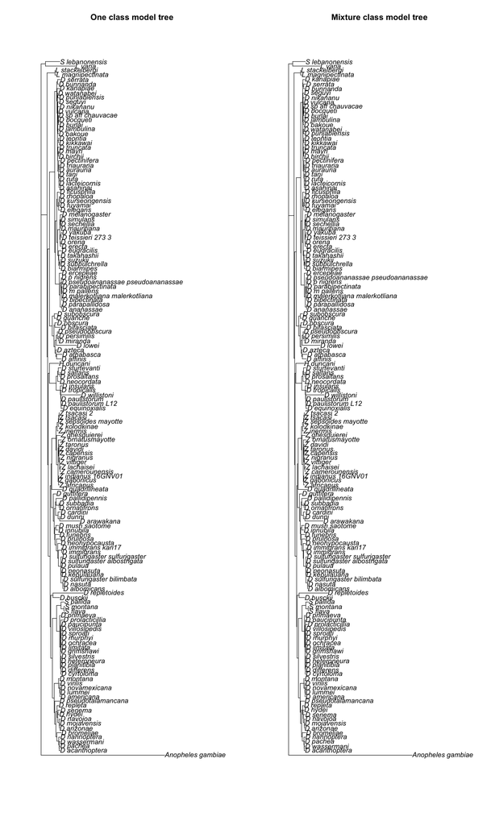

```r
par(mfrow = c(1, 2))  # Set the plotting layout to 1 row and 2 columns
plot(one_tree, main = "One class model tree")  # Plot the first tree
plot(mix_tree, main = "Mixture class model tree")  # Plot the second tree
```

```r
## create co-phylogenetic object
wasp.cophylo<-cophylo(mix_tree,one_tree)
```

```
## Rotating nodes to optimize matching...
## Done.
```

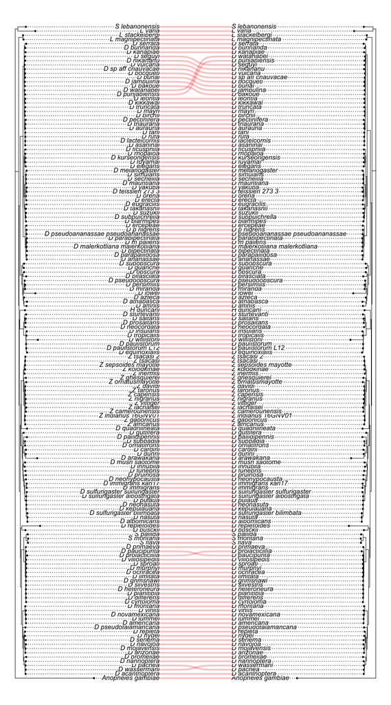

```r
## plot co-phylogenies
plot(wasp.cophylo,link.type="curved",link.lwd=4,
 link.lty="solid",link.col=make.transparent("red",
 0.25))
```

```r
par(mar=c(5.1,4.1,4.1,2.1))
```

1. D watanabei D punjabiensis was either have paraphyletic relationships to D. kikkawai and D. leontia or have paraphyletic relationships with D. seguy, D. nikananu, D. vulcana, D spaffchauvacae, D bocquet, D burlai, D. jambulina, D. bakoue
2. D wassermani form monophyletic lineage sister to the D. acanthoptera or have paraphyletic relationships where D pachea is sister to the D. acanthoptera
3. D paucipunta form monophyletic lineage sister to the D prolacticillia or have paraphyletic relationships with the D prolacticillia

### **Branch Lengths**

```r
library(phangorn)
# Calculate the Robinson-Foulds distance
rf_distance <- treedist(one_tree, mix_tree)

# Display the RF distance
cat("Robinson-Foulds distance:", rf_distance, "\n")
```

```
## Robinson-Foulds distance: 14 0.6735708 91.94564 10.17752
```

The Robinson-Foulds (RF) distance quantify the dissimilarity or difference between two phylogenetic trees. It calculates the number of bipartitions (splitting of the taxa into two groups) that are present in one tree but not in the other, plus the number of bipartitions that are present in the second tree but not in the first.

### **Best Model and Parameters**

```
### Read the IQ-TREE file
```

```r
one_line <- readLines('~/Desktop/BIOL8706/phylogenetic_project/Phylogenetic_project/Data/one_class_single_gene/one_class_EOG09150A0E.iqtree')
mix_line <- readLines("~/Desktop/BIOL8706/phylogenetic_project/Phylogenetic_project/Data/mixture_class_single_gene/mix_class_EOG09150A0E.iqtree")
```

```
### Extract best-fit model(one-class & mixture class)
```

```r
library(data.table)
library(stringr)
one_model <- grep("^Model of substitution:", one_line, value = TRUE)
one_class_mod_lines <- one_line[(which(one_line == one_model)):(which(one_line == one_model)+9)]
one_class_mod_table <- data.table(Line = one_class_mod_lines)
setnames(one_class_mod_table, new = "One Class Model")
one_class_mod_table
```

```
##                       One Class Model
##  1: Model of substitution: TIM2e+I+R4
##  2:
##  3:                 Rate parameter R:
##  4:
##  5:                       A-C: 1.3727
##  6:                       A-G: 2.7277
##  7:                       A-T: 1.3727
##  8:                       C-G: 1.0000
##  9:                       C-T: 4.7261
## 10:                       G-T: 1.0000
```

```r
mix_model <- grep("^Mixture model of substitution:", mix_line, value = TRUE)
mix_df1 <- data.table(Line = mix_model)
setnames(mix_df1, new = "Mix Class Model")
```

```r
# Example lines
Component_mix_model <- mix_line[(which(mix_line == mix_model)+3):(which(mix_line == mix_model)+6)]
# Initialize an empty vector to store words
all_words <- c()
# Iterate through each line
for (line in Component_mix_model) {
words <- strsplit(line, " ")[[1]]
      non_empty_words <- words[words != ""]
      all_words <- c(all_words, non_empty_words)
    }

    matrix_data <- matrix(all_words,
                       nrow = 3, ncol = 5, byrow = TRUE)
# Convert the matrix into a data frame
mix_df2 <- as.data.frame(matrix_data)

# Add row and column names
colnames(mix_df2) <- c("No", "Component", "Rate", "Weight", "Parameters")

combined_mod_mix_df <- rbind(mix_df1, mix_df2,fill = TRUE)
combined_mod_mix_df
```

```
##                                               Mix Class Model   No Component
## 1: Mixture model of substitution: MIX{TIM2+FO,JC,HKY+FO}+I+G4 <NA>      <NA>
## 2:                                                       <NA>    1      TIM2
## 3:                                                       <NA>    2        JC
## 4:                                                       <NA>    3       HKY
##      Rate Weight
## 1:   <NA>   <NA>
## 2: 1.0000 0.4908
## 3: 1.0000 0.3430
## 4: 1.0000 0.1662
##                                                              Parameters
## 1:                                                                 <NA>
## 2: TIM2{1.98418,8.94168,15.2375}+FO{0.17763,0.233357,0.305017,0.283996}
## 3:                                                                   JC
## 4:                HKY{2.99314}+FO{0.375944,0.415568,0.0779491,0.130539}
```

### **Model Evaluation: BIC Score, AIC Score, and Likelihood:**

```r
one_BIC <- grep("MAXIMUM LIKELIHOOD TREE", one_line, value = TRUE)
one_BIC_lines <- one_line[(which(one_line == one_BIC)+2):(which(one_line == one_BIC)+11)]
one_BIC_table <- data.table(Line = one_BIC_lines)
setnames(one_BIC_table, new = "ONE CLASS MODEL")
print(one_BIC_table)
```

```
##                                                      ONE CLASS MODEL
##  1:
##  2:          Log-likelihood of the tree: -24722.0640 (s.e. 872.7689)
##  3:         Unconstrained log-likelihood (without tree): -11045.4974
##  4:   Number of free parameters (#branches + #model parameters): 317
##  5:             Akaike information criterion (AIC) score: 50078.1279
##  6:  Corrected Akaike information criterion (AICc) score: 50201.1371
##  7:           Bayesian information criterion (BIC) score: 51846.7242
##  8:
##  9:                Total tree length (sum of branch lengths): 9.7422
## 10: Sum of internal branch lengths: 2.5724 (26.4050% of tree length)
```

```r
mix_BIC <- grep("MAXIMUM LIKELIHOOD TREE", mix_line, value = TRUE)
mix_BIC_lines <- mix_line[(which(mix_line == mix_BIC)+2):(which(mix_line == mix_BIC)+11)]
mix_BIC_table <- data.table(Line = mix_BIC_lines)
setnames(mix_BIC_table, new = "MIX CLASS MODEL")
```

```r
combined_BIC_df <- cbind(one_BIC_table,mix_BIC_table)
print(combined_BIC_df)
```

```
##                                                      ONE CLASS MODEL
##  1:
##  2:          Log-likelihood of the tree: -24722.0640 (s.e. 872.7689)
##  3:         Unconstrained log-likelihood (without tree): -11045.4974
##  4:   Number of free parameters (#branches + #model parameters): 317
##  5:             Akaike information criterion (AIC) score: 50078.1279
##  6:  Corrected Akaike information criterion (AICc) score: 50201.1371
##  7:           Bayesian information criterion (BIC) score: 51846.7242
##  8:
##  9:                Total tree length (sum of branch lengths): 9.7422
## 10: Sum of internal branch lengths: 2.5724 (26.4050% of tree length)
##                                                      MIX CLASS MODEL
##  1:
##  2:          Log-likelihood of the tree: -24506.9433 (s.e. 863.3187)
##  3:         Unconstrained log-likelihood (without tree): -11045.4974
##  4:   Number of free parameters (#branches + #model parameters): 321
##  5:             Akaike information criterion (AIC) score: 49655.8866
##  6:  Corrected Akaike information criterion (AICc) score: 49782.3233
##  7:           Bayesian information criterion (BIC) score: 51446.7995
##  8:
##  9:               Total tree length (sum of branch lengths): 11.4917
## 10: Sum of internal branch lengths: 2.8861 (25.1151% of tree length)
```

## **References:**

Suvorov A, Kim BY, Wang J, Armstrong EE, Peede D, D’Agostino ERR, Price DK, Waddell P, Lang M, Courtier-Orgogozo V, David JR, Petrov D, Matute DR, Schrider DR, Comeault AA. Widespread introgression across a phylogeny of 155 Drosophila genomes. Curr Biol. 2022 Jan 10;32(1):111-123.e5. doi: 10.1016/j.cub.2021.10.052. Epub 2021 Nov 16. PMID: 34788634; PMCID: PMC8752469.

Suvorov, Anton; Kim, Bernard; Wang, Jeremy; Armstrong, Ellie; Peede, David; D’Agostino, Emmanuel R. R.; et al. (2020). Widespread introgression across a phylogeny of 155 Drosophila genomes. figshare. Dataset. https://doi.org/10.6084/m9.figshare.13264697.v1